# Comparação de métodos de imputação para séries temporais univariadas

## 3.2 Simulação de valores ausentes

Como visto no gráfico, a série temporal `AirPassengers` não possui valores ausentes. Neste texto, foi simulada uma situação em que a série possua uma porcentagem de falhas igual a 25%. Ou seja, 25% das observações foram removidas de forma completamente aleatória.

Dada a porcentagem de falhas, calcula-se quantos valores serão removidos com base no tamanho da série. Como `AirPassengers` possui 144 observações, 25% de ausência de dados significa que 36 valores serão removidos aleatoriamente. Para isto, foi usada a função `sample` para sortear 36 números entre 1 e 144. Os números sorteados são os índices de `AirPassengers` que serão removidos, para se tornarem falhas. Por fim, cria-se uma nova variável igual a `AirPassengers` e atribui o valor `NA` nos índices sorteados. Como a simulação envolve aleatoriedade, foi definida uma semente geradora de números aleatórios para garantir a reprodutibilidade do código, usando a função `set.seed`. O código abaixo mostra como realizar esta simulação.

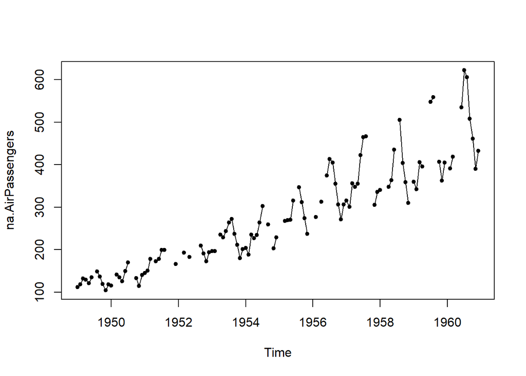

```r
# Para garantir a reprodutibilidade deste código
set.seed(1)

# Número de observações (tamanho) da série
len <- length(AirPassengers)

# Porcentagem de falhas a ser simulada
perc <- 0.25

# Número de observações que de fato serão removidas
tot <- round(perc * len)

# Cria um vetor auxiliar com números de 1 a 'len'
index <- 1:len

# Seleciona aleatoriamente as posições cujas falhas serão criadas
na.index <- sample(index, size = tot)

# Copia a série para uma nova variável
na.AirPassengers <- AirPassengers

# Cria as falhas nas posições selecionadas aleatoriamente
na.AirPassengers[na.index] <- NA

# Visualiza a nova série com falhas
plot(na.AirPassengers, type = 'o', pch = 20)
```

Agora, a série temporal `na.AirPassengers` possui falhas e pode ser usada para a aplicação dos métodos de imputação. Os valores originais são conhecidos e estão armazenados na série `AirPassengers`.

## 3.3 Comparação dos resultados

Para comparar os métodos de imputação, foi usado o pacote `imputeTS` [4]. Os métodos da interpolação linear e por spline, médias móveis e imputação com decomposição STL foram usados para preencher as falhas da série `na.AirPassengers`.

Primeiramente, deve-se instalar e carregar o pacote no **R**.

```r
install.packages(imputeTS)
library(imputeTS)
```

Em seguida, os métodos foram aplicados e o resultado da imputação de cada método foi armazenado em sua respectiva variável.

```r
# Interpolação linear
imp.interp <- na_interpolation(na.AirPassengers)

# Interpolação por spline
imp.spline <- na_interpolation(na.AirPassengers, option = "spline")

# Imputação por médias móveis
imp.ma <- na_ma(na.AirPassengers)

# Imputação com decomposição STL
imp.seadec <- na_seadec(na.AirPassengers)
```

Finalmente, a partir dos valores originais da série `AirPassengers` e dos valores estimados por cada método para preencher a série `na.AirPassengers`, foi possível calcular o MSE.

```r
# Função para calcular o MSE
mse <- function(previsto, original) {
  return(mean((previsto - original)^2))
}

# Calcula o MSE
mse.interp <- mse(imp.interp[na.index], AirPassengers[na.index])
mse.spline <- mse(imp.spline[na.index], AirPassengers[na.index])
mse.ma <- mse(imp.ma[na.index], AirPassengers[na.index])
mse.seadec <- mse(imp.seadec[na.index], AirPassengers[na.index])
```

Os resultados do MSE são mostrados na tabela abaixo.

```
##   interp   spline       ma   seadec
##  391.316 353.1816 642.5688 143.7929
```

Segundo o MSE, o método da imputação com decomposição STL obteve o melhor resultado, seguido pelos métodos da interpolação por *spline*, interpolação linear e médias móveis. Este resultado sugere que o método mais robusto, que usa a decomposição da série para a imputação, foi superior em relação aos outros métodos avaliados.

# 4 Considerações finais

Este texto comparou diferentes métodos de imputação de valores ausentes em séries temporais em linguagem **R**. Uma série temporal conhecida foi usada como caso de estudo. A simulação de valores ausentes realizada permitiu avaliar e comparar o desempenho dos métodos. O método mais robusto, que se baseia na decomposição da série temporal, mostrou o melhor resultado.

# 5 Referências

[1]

R. B. Cleveland, W. S. Cleveland, J. E. McRae, and I. Terpenning, “STL: A seasonal-trend decomposition procedure based on loess,” *Journal of Official Statistics*, vol. 6, no. 1, pp. 3–33, 1990.

[2]

W. S. Cleveland and S. J. Devlin, “Locally weighted regression: An approach to regression analysis by local fitting,” *Journal of the American statistical association*, vol. 83, no. 403, pp. 596–610, 1988, doi: https://doi.org/10.1080/01621459.1988.10478639.

[3]

R. J. Hyndman and G. Athanasopoulos, *Forecasting: Principles and practice*. Melbourne, Australia: OTexts, 2018. Available: https://www.OTexts.com/fpp2

[4]

S. Moritz and T. Bartz-Beielstein, “imputeTS: Time Series Missing Value Imputation in R,” *The R Journal*, vol. 9, no. 1, pp. 207–218, 2017, doi: https://doi.org/10.32614/RJ-2017-009.